# AI Impact on Jobs 2030 - Insights

## Notebook 3 : Descriptive Exploration by Risk Category

In Notebook 2, rigorous statistical analyses examined the relationships between automation probability and classical job characteristics such as salary, years of experience, education level, and AI exposure. These analyses—including parametric and non-parametric tests as well as mixed-effects Beta regression—consistently showed weak or non-significant effects for individual-level predictors, suggesting that these standard attributes alone cannot explain variation in automation risk.

However, a strong effect of job title emerged, highlighting that occupational identity and task composition are central to automation vulnerability. Highly skilled, knowledge-intensive professions exhibit low automation probability, whereas routine, manual, and service-oriented occupations face substantially higher risk.

Given these findings, Notebook 3 focuses on descriptive exploration within each Risk_Category, aiming to finally address the guiding question:

**“Which types of jobs are most at risk of automation, and how do job characteristics are distributed across different levels of automation risk?”**

By examining counts, top skills, and distributions of key metrics (salary, experience, AI exposure, technological growth), this approach provides a complementary perspective that highlights patterns and heterogeneity not evident in previous statistical analyses, offering deeper insights into the factors driving automation risk across occupations.

Author: J-F Jutras  
Date: December 2025  
Dataset: AI Impact on Jobs 2030 — Kaggle

## Automation Probability by Job Title

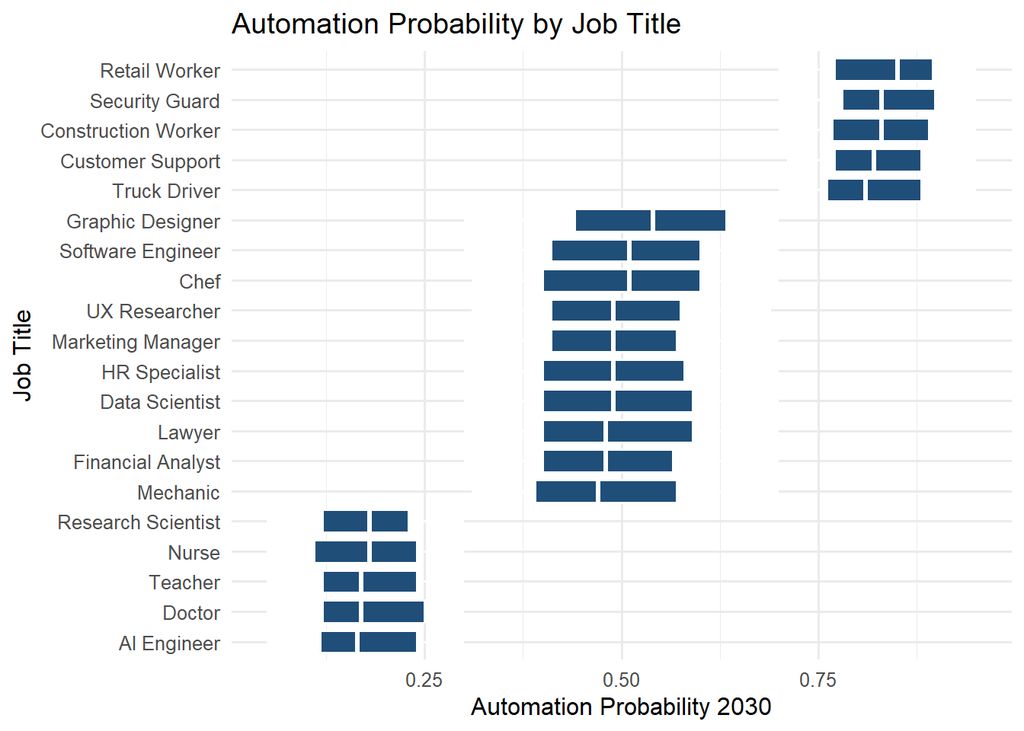

This boxplot illustrates the distribution of automation probability across all job titles. High variation is observed among certain occupations, highlighting that automation risk is primarily structured by job title rather than individual attributes.

## Number of Observations by Risk Category and Job Title

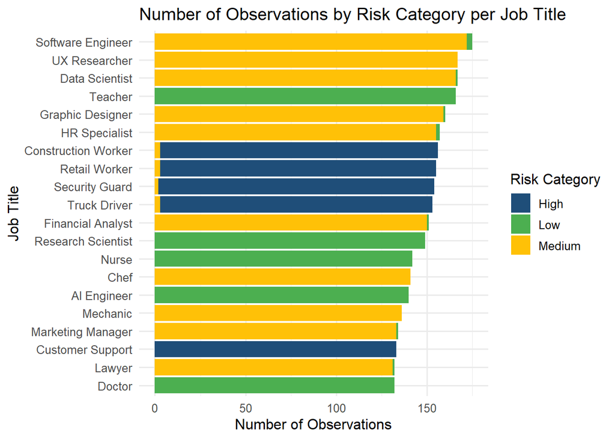

This stacked bar chart provides an alternative view compared to the previous boxplots of automation probability by job title, since the Risk Category is derived from automation probability. High-risk jobs are concentrated in routine and service-oriented occupations, while Low-risk jobs are predominantly knowledge-intensive, highlighting the occupational stratification of automation risk.

## Characteristics of Jobs by Risk Category

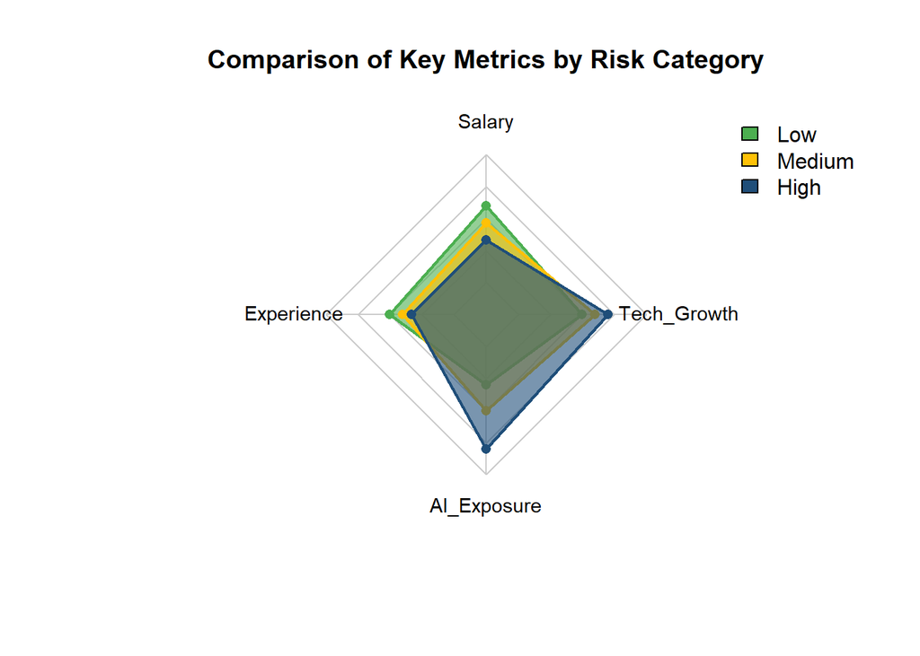

This radar chart summarizes the central tendencies of key metrics (Salary, Experience, AI Exposure, Tech Growth) for Low, Medium, and High-risk jobs. It allows quick visual comparison across Risk_Categories, complementing the previous detailed plots and illustrating overall patterns despite non-significant statistical differences.

## Characteristics of High-Risk Jobs

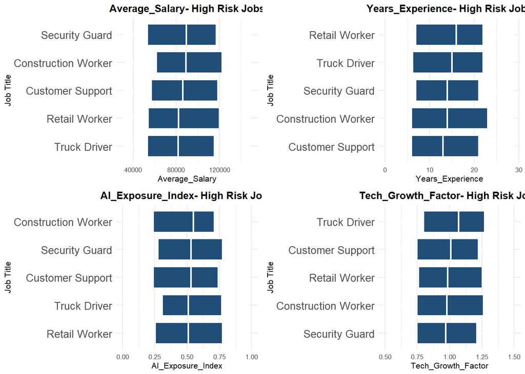

Overall, these visualizations confirm that high-risk jobs are not uniform; they vary significantly in salary, experience, AI exposure, and technology growth sensitivity, highlighting the heterogeneous nature of occupations most vulnerable to automation.

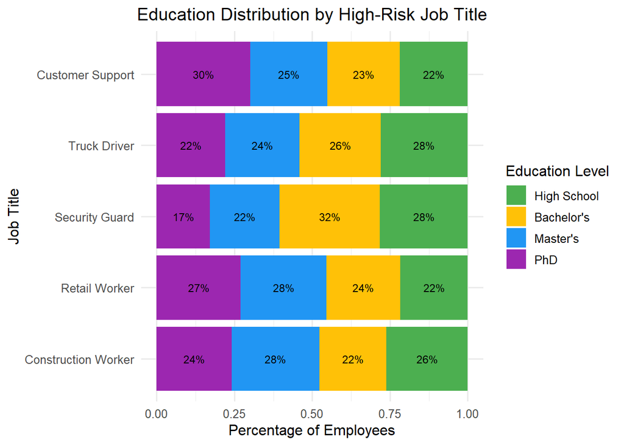

High-risk jobs show diverse education profiles. PhDs dominate in Customer Support (30%), while lower degrees are more common in Security Guards (32% Bachelor’s) and Truck Drivers (28% High School). Retail and Construction roles are more evenly spread. Overall, education varies within jobs, not consistently between jobs.

[interactive chart not shown]

This 3D scatter plot of high-risk jobs illustrates the substantial intra-occupational heterogeneity. Points are widely dispersed across salary, experience, AI exposure, and technological growth dimensions, indicating that even within high-risk job titles, individuals vary considerably in their profiles.

## Key Takeaways: Insights

**Answering the guiding question: “Which types of jobs are most at risk of automation, and how do job characteristics distribute across different levels of automation risk?”**

The analysis confirms that automation risk is primarily structured by occupation: high-risk jobs are mostly routine, manual, or service-oriented, while low-risk jobs are knowledge-intensive. However, within high-risk occupations, there is substantial heterogeneity in salary, years of experience, AI exposure, technological growth, and even education levels.

This means that while we can confidently classify jobs at a high or low risk level, describing more specific characteristics for individual roles is limited. Median or average values provide only a rough overview, and they do not capture the full range of variability within each occupation. As such, the main insight is that risk is occupation-driven rather than determined by individual attributes.

## Limitations

- **Simulated data**: The dataset is simulated, with multiple rows per job title representing variations rather than distinct positions, limiting real-world validity.
- **Small number of unique job titles**: Only 20 unique job titles are included, restricting representativeness and potentially exaggerating within-job variability.
- **High intra-job heterogeneity**: Even within high-risk jobs, salary, experience, AI exposure, tech growth, and education vary widely, making it difficult to assign definitive characteristics to a given occupation.
- **Limited explanatory variables**: The dataset does not include task complexity, organizational adoption of AI, regulatory constraints, or temporal changes, which could influence automation risk.
- **Correlation vs causation**: Analyses show associations but cannot establish causal relationships between job characteristics and automation probability.
- **Scaling and generalizability**: Observations are based on simulated 2030 projections; real labor market dynamics may differ significantly.